# Modelos de ocupación una temporada/una especie

Karen Velásquez

## Librerías

```r
library(vegan)
library(corrplot)
library(usdm)
library(unmarked)
library(MuMIn)
library(AICcmodavg)
library(ggplot2)
```

## Covariables

Cargamos la base de datos con la información de las variables, eliminando la columna de sitio o cámara.

```r
covar <- read.csv("CovariablesOcc.csv", sep=",")
cov.site <- covar[,-1]
```

Extraemos las variables numéricas y se estandarizan mediante la función `decostand`, incluyendo el objeto con la información de las variables y el método, para este caso `standardize`. A continuación extraemos las covariables categóricas como un factor.

```r
cov.num<-cov.site[,sapply(cov.site,is.numeric)]
cov.std<-decostand(cov.num,method="standardize")
CAM<-cov.site[,sapply(cov.site,is.character)]
```

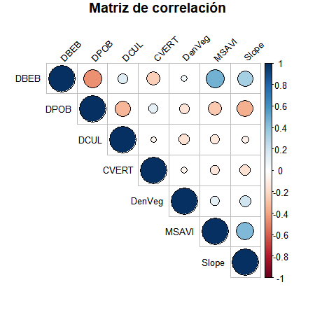

Correlación de las variables seleccionadas.

```r
cormat <- cor(cov.std)
corrplot(cormat, method = c("circle"), type = "upper", outline = T, tl.col = "black", tl.cex = 0.8, tl.srt = 45,  mar = c(2,0,1,1.5), title = "Matriz de correlación")
```

```r
usdm::vif(cov.std)
```

```
##   Variables      VIF
## 1      DBEB 1.593934
## 2      DPOB 1.582294
## 3      DCUL 1.282933
## 4     CVERT 1.077476
## 5    DenVeg 1.093257
## 6     MSAVI 1.513401
## 7     Slope 1.406977
```

```r
no_corr <- vifstep(cov.std, th=4)
no_corr
```

```
## No variable from the 7 input variables has collinearity problem.
##
## The linear correlation coefficients ranges between:
## min correlation ( CVERT ~ DCUL ):  -0.05402051
## max correlation ( MSAVI ~ DBEB ):  0.4737214
##
## ---------- VIFs of the remained variables --------
##   Variables      VIF
## 1      DBEB 1.593934
## 2      DPOB 1.582294
## 3      DCUL 1.282933
## 4     CVERT 1.077476
## 5    DenVeg 1.093257
## 6     MSAVI 1.513401
## 7     Slope 1.406977
```

```r
covs<-data.frame(CAM, cov.std)
```

## Construcción de los modelos

Para la construcción de los modelos iniciaremos cargando la librería `unmarked` Fiske and Chandler (2011).

Para generar el marco de datos a emplear en los modelos se debe cargar la base de datos correspondiente a las historias de detección de la especie de interés. En este caso se trabajará con registros de la zorra gris *Urocyon cinereoargenteus* obtenidos a partir de información de foto trampeo en la localidad de San Gabriel Casa Blanca, Oaxaca.

```r
Urci <- read.csv("DetHist_UrciClase.csv", sep=",")
Urcihist <- Urci[,-1]
UmUr <- unmarkedFrameOccu(y=Urcihist,
                          siteCovs=covs,
                          obsCovs= NULL)
summary(UmUr)
```

```
## unmarkedFrame Object
##
## 54 sites
## Maximum number of observations per site: 60
## Mean number of observations per site: 24.24
## Sites with at least one detection: 41
##
## Tabulation of y observations:
##    0    1 <NA>
## 1110  199 1931
##
## Site-level covariates:
##           CAM          DBEB              DPOB               DCUL
##  Moultrie   :11   Min.   :-1.8696   Min.   :-1.57585   Min.   :-2.13312
##  MoultrieA30:20   1st Qu.:-0.6888   1st Qu.:-0.95770   1st Qu.:-0.60066
##  Primos     :23   Median : 0.1805   Median :-0.05745   Median :-0.07604
##                   Mean   : 0.0000   Mean   : 0.00000   Mean   : 0.00000
##                   3rd Qu.: 0.7343   3rd Qu.: 0.76136   3rd Qu.: 0.62852
##                   Max.   : 1.7180   Max.   : 1.79225   Max.   : 2.39148
##      CVERT             DenVeg            MSAVI              Slope
##  Min.   :-1.1581   Min.   :-0.8783   Min.   :-4.41695   Min.   :-1.1452
##  1st Qu.:-0.9159   1st Qu.:-0.5898   1st Qu.:-0.41921   1st Qu.:-0.8207
##  Median : 0.0458   Median :-0.3325   Median : 0.06047   Median :-0.1769
##  Mean   : 0.0000   Mean   : 0.0000   Mean   : 0.00000   Mean   : 0.0000
##  3rd Qu.: 0.6197   3rd Qu.: 0.2546   3rd Qu.: 0.60488   3rd Qu.: 0.7647
##  Max.   : 2.4573   Max.   : 5.1577   Max.   : 1.47659   Max.   : 3.1124
```

```r
str(UmUr)
```

```
## Formal class 'unmarkedFrameOccu' [package "unmarked"] with 5 slots
##   ..@ y       : int [1:54, 1:60] NA NA NA NA NA NA 0 NA NA NA ...
##   .. ..- attr(*, "dimnames")=List of 2
##   .. .. ..$ : NULL
##   .. .. ..$ : chr [1:60] "detection_history.o1" "detection_history.o2" "detection_history.o3" "detection_history.o4" ...
##   ..@ obsCovs : NULL
##   ..@ siteCovs:'data.frame': 54 obs. of  8 variables:
##   .. ..$ CAM   : Factor w/ 3 levels "Moultrie","MoultrieA30",..: 2 1 2 3 2 3 2 1 2 3 ...
##   .. ..$ DBEB  : num [1:54] 0.521 0.345 0.257 0.104 -0.107 ...
##   .. ..$ DPOB  : num [1:54] -0.653 -0.393 -0.133 -0.639 -0.38 ...
##   .. ..$ DCUL  : num [1:54] 0.573 1.499 2.391 0.318 1.157 ...
##   .. ..$ CVERT : num [1:54] -0.435 0.769 -0.916 -0.916 -1.158 ...
##   .. ..$ DenVeg: num [1:54] -0.81 -0.717 -0.364 0.247 -0.138 ...
##   .. ..$ MSAVI : num [1:54] 0.6154 -1.2552 -1.0221 -0.2684 -0.0107 ...
##   .. ..$ Slope : num [1:54] -0.184 -1.10549 -1.14517 1.71077 0.00522 ...
##   ..@ mapInfo : NULL
##   ..@ obsToY  : num [1:60, 1:60] 1 0 0 0 0 0 0 0 0 0 ...
```

### Proceso observacional

```r
summary(fmUr1 <- occu(~1~1, data=UmUr))
```

```
##
## Call:
## occu(formula = ~1 ~ 1, data = UmUr)
##
## Occupancy (logit-scale):
##  Estimate  SE   z P(>|z|)
##      15.5 NaN NaN     NaN
##
## Detection (logit-scale):
##  Estimate    SE     z   P(>|z|)
##     -1.72 0.077 -22.3 1.99e-110
##
## AIC: 1119.804
## Number of sites: 54
## optim convergence code: 0
## optim iterations: 13
## Bootstrap iterations: 0
```

El modelo nulo representa la interpretación más sencilla tanto del proceso ecológico como observacional, en la que estos no están siendo afectados por ningún factor externo.

Al finalizar la computación de los modelos los organizaremos mediante la función `fitlist`, permitiéndonos así evaluar el mejor modelo usando la función `modSel`. Seleccionaremos el mejor modelo que represente la probabilidad de detección mediante el criterio de información de Akaike (AIC), seleccionando así el modelo con menor valor de AIC.

```r
fms <- fitList ("p(.)psi(.)"            = fmUr1,
                "p(CAM)psi(.)"          = fmUr2,
                "p(CVERT)psi(.)"        = fmUr3,
                "p(DenVeg)psi(.)"        = fmUr4)
(ms <- modSel(fms))
```

```
##                 nPars     AIC delta   AICwt cumltvWt
## p(DenVeg)psi(.)     3 1066.84  0.00 9.8e-01     0.98
## p(CAM)psi(.)        4 1075.34  8.49 1.4e-02     1.00
## p(CVERT)psi(.)      3 1078.67 11.82 2.7e-03     1.00
## p(.)psi(.)          2 1119.80 52.96 3.1e-12     1.00
```

### Proceso ecológico

Al igual que en los modelos construidos para la detección, organizamos en una lista los modelos y con la función `modSel` obtenemos los datos organizados de los modelos según el valor de AIC.

```
##                     nPars     AIC delta AICwt cumltvWt
## p(DenVeg)psi(DCUL)      4 1063.21  0.00 0.733     0.73
## p(DenVeg)psi(MSAVI)     4 1067.85  4.64 0.072     0.80
## p(DenVeg)psi(DPOB)      4 1068.40  5.19 0.055     0.86
## p(DenVeg)psi(CVERT)     4 1068.65  5.44 0.048     0.91
## p(DenVeg)psi(DBEB)      4 1068.69  5.48 0.047     0.95
## p(DenVeg)psi(Slope)     4 1068.77  5.57 0.045     1.00
```

Con el fin de obtener el valor de probabilidad de detección y ocupación real de la especie, realizamos una transformación de los valores estimados obtenidos mediante la función `backTransform`

```r
backTransform(linearComb(fmUr5, coefficients=c(1,0), type="state"))
```

```
## Backtransformed linear combination(s) of Occupancy estimate(s)
##
##  Estimate   SE LinComb (Intercept) DCUL
##     0.847 0.06    1.71           1    0
##
## Transformation: logistic
```

```r
backTransform(linearComb(fmUr5, coefficients=c(1,0), type="det"))
```

```
## Backtransformed linear combination(s) of Detection estimate(s)
##
##  Estimate     SE LinComb (Intercept) DenVeg
##      0.18 0.0123   -1.52           1      0
##
## Transformation: logistic
```

### Importancia de las covariables

- Intervalos de confianza modelo fmUr5

```r
confint(fmUr5, type="state")
```

```
##                0.025       0.975
## psi(Int)   0.8048265  2.62207770
## psi(DCUL) -1.7650735 -0.07716598
```

```r
confint(fmUr5, type="det")
```

```
##                0.025      0.975
## p(Int)    -1.6827780 -1.3545926
## p(DenVeg) -0.6193919 -0.1572371
```

### Prueba de bondad de ajuste

En algunos casos el o los mejores modelos no siempre son un “buen” modelo, esto quiere decir que no nos ayuda a explicar lo que realmente esta pasando. Para saber si un modelo es bueno, el siguiente paso es aplicar una prueba de bondad de ajuste. En este caso aplicaremos la prueba desarrollada por MacKenzie and Bailey (2004) con el fin de identificar si nuestro modelo se ajusta de manera adecuada. Para la realización de la prueba es necesario cargar la librería `AICcmodavg`, y se emplea la función `mb.gof.test` como se ejemplifica a continuación:

```
mb_Urci5clase <- mb.gof.test(fmUr5, nsim = 500, plot.hist = TRUE)
```

Resultado fmUr5

[output not shown]

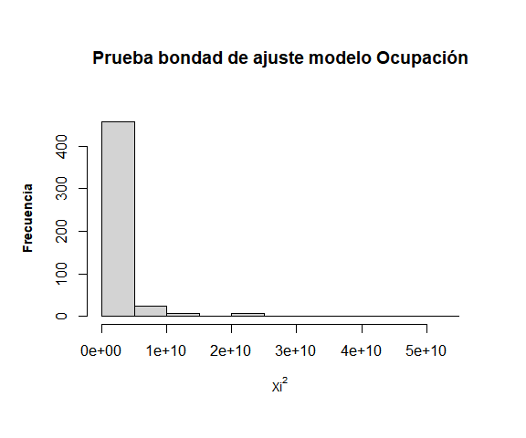

Histograma correspondiente a la prueba de bondan de ajuste .

```r
par(mar = c(6.50,
            5.00,
            6.50,
            3.00))
hist(mb_Urci5clase$t.star, xlab=expression(paste("Xi"^"2")), ylab="Frecuencia", col="lightgrey",
     font.lab=2, cex.lab=0.9, main="Prueba bondad de ajuste modelo Ocupación")
abline(v=mb_Urci5clase$chi.square, lty=2, lwd=3, col="red")
```

Como resultado de la prueba tenemos dos parámetros informativos:

1. El resultado de la prueba Xi2 de nuestro estimador y el remuestreo. Si la prueba presenta un *p*-valor <0.05 quiere decir que el modelo no se ajusta de manera adecuada.
2. El c-hat es un parámetro que nos informa sobre la dispersión del modelo, cuando un modelo esta bien ajustado el c-hat es igual a 1, en caso de tener sobre dispersión el valor será >1 y subdispersión cuando sea <1.

En nuestro caso, el modelo no se ajusta de manera adecuada (Figura 1), y presenta un alto nivel de sobredispersión. Esto puede deberse a diferentes factores; ya sea que las covariables que medimos no sean las adecuadas o que nuestra cantidad de registros sea baja en comparación con los ceros.

### Visualización de resultados

La mejor alternativa para la visualización de las predicciones tanto de la probabilidad de detección como de ocupación es mediante gráficos, ya que nos permite ver como se comporta la detección y la ocupación a partir de las variables incorporadas.

Para la realización de los gráficos cargaremos la paquetería `ggplot2`:

La generación de los gráficos de predicción se obtienen a partir del siguiente código:

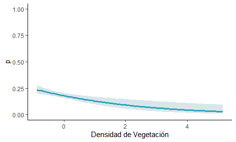

```r
newData <- data.frame(DenVeg=seq(min(covs$DenVeg),max(covs$DenVeg), length=100))
statepredict <-predict(fmUr5, type="det", newdata=newData, appendData=TRUE)
DenVegplot <- ggplot(statepredict,aes(x=DenVeg,y=Predicted))+ylim(0,1)+
  labs(x="Densidad de Vegetación",y="p")+
  geom_ribbon(data = statepredict,aes(ymin=lower,ymax=upper),alpha=0.8, fill = "#cfe0e3")+
  geom_line(data = statepredict, colour="#2aa3bb", size=1.2)+
  theme_classic()
DenVegplot
```

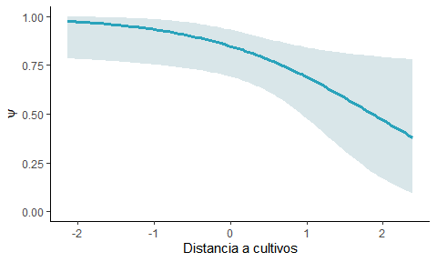

# Bibliografía

Fiske, Ian, and Richard Chandler. 2011. “Unmarked: An R Package for Fitting Hierarchical Models of Wildlife Occurrence and Abundance.” *Journal of Statistical Software* 43 (10): 1–23.

MacKenzie, Darryl I, and Larissa L Bailey. 2004. “Assessing the Fit of Site-Occupancy Models.” *Journal of Agricultural, Biological, and Environmental Statistics* 9 (3): 300–318.

Naimi, B. 2015. “Package ‘Usdm’. Uncertainty Analysis for Species Distribution Models.”

Robinson, Cecil, and Randall E Schumacker. 2009. “Interaction Effects: Centering, Variance Inflation Factor, and Interpretation Issues.” *Multiple Linear Regression Viewpoints* 35 (1): 6–11.

Wei, Taiyun, Viliam Simko, Michael Levy, Yihui Xie, Yan Jin, and Jeff Zemla. 2017. “Package ‘Corrplot’.” *Statistician* 56: 316–24.

Zuur, Alain, Elena N Ieno, Neil Walker, Anatoly A Saveliev, and Graham M Smith. 2009. *Mixed Effects Models and Extensions in Ecology with R*. Springer Science & Business Media.